# ProjectM3-checkpoint

ProjectM3A Chris Troop

Reflection Questions:

Part1 y=0.75x-0.9 was the best decsion boundry based on visual inspection. The accuracy score for this boundry was the lowest and I don't understand that. The boundry with the highest accuracy score was the worst visual fit.I seems that the accuracy score is weighted for getting one category correct rather than than both.

Part2 the petal classes were much easier to speperate than the sepal. If the classes create nice clusters it is much easier to fit a boundry to visually.

Part3

1. Testing accuracy scores are a better evaluation of the models predictive ability because the model should test the best on the training data becasue thats what was used to build the model.
2. If you train and test on the same data, you should get the best results because the model was designed based on that training data. Training data may not be respresentative of the full data set.
3. If you withhold some of the data for testing, you could testing with if becasue the model would not have factored those points into its construction.

Part4

1. Logistical considers all data points which could lead to some influence of outliers. SVM focuses on the distance to the boundry rather than the probability of belonging to the specific class.
2. The planes can not be interpret the same way. Logitical can be interperated probabilistically while SVM cannot.
3. Logistic regression is easy to interperate probabilistically but can be easily influenced by outliers. SVM is robust to outliers but it is hard to interpretate because it does not have a probabilistic output.

```python
import pandas as pd
import numpy as np
import matplotlib.pyplot as plt
import seaborn as sns
from decision_boundaries import linear_decision_boundary_classifier
from sklearn.metrics import accuracy_score
from sklearn.preprocessing import LabelEncoder
le = LabelEncoder()
from sklearn.linear_model import LogisticRegression
from sklearn.pipeline import make_pipeline
from sklearn.preprocessing import StandardScaler
from sklearn.svm import SVC
```

```python
setosa_df = pd.read_csv("setosa_data.csv")

setosa_df.head()
```

|  | label | sepal_length (cm) | sepal_width (cm) |
| --- | --- | --- | --- |
| 0 | not setosa | 5.1 | 3.5 |
| 1 | not setosa | 4.9 | 3.0 |
| 2 | not setosa | 4.7 | 3.2 |
| 3 | not setosa | 4.6 | 3.1 |
| 4 | not setosa | 5.0 | 3.6 |

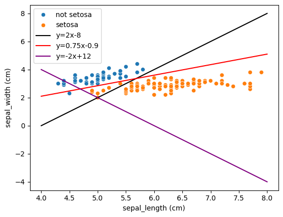

```python
sns.scatterplot(x="sepal_length (cm)", y="sepal_width (cm)", hue="label", data= setosa_df)
plt.plot([4, 8], [0, 8], 'black', label = "y=2x-8")
plt.plot([4, 8], [2.1, 5.1], 'red', label = "y=0.75x-0.9")
plt.plot([4, 8], [4, -4], 'purple', label = "y=-2x+12")
plt.legend()
plt.rcParams['savefig.dpi'] = 300
plt.show()
```

standard form

-2x+y+8=0 -0.75+y+0.9=0 2x+y-12=0

```python
dec_bound_vec = np.array([-2, 1.00, 8])
features = setosa_df[["sepal_length (cm)", "sepal_width (cm)"]].values
class_names = ["not setosa", "setosa"]
pred_labels = linear_decision_boundary_classifier(dec_bound_vec, features, class_names=class_names)
print(pred_labels)

print (accuracy_score(setosa_df['label'], pred_labels))
```

```
['setosa' 'setosa' 'setosa' 'setosa' 'setosa' 'setosa' 'setosa' 'setosa'
 'setosa' 'setosa' 'setosa' 'setosa' 'setosa' 'setosa' 'setosa' 'setosa'
 'setosa' 'setosa' 'setosa' 'setosa' 'setosa' 'setosa' 'setosa' 'setosa'
 'setosa' 'setosa' 'setosa' 'setosa' 'setosa' 'setosa' 'setosa' 'setosa'
 'setosa' 'setosa' 'setosa' 'setosa' 'setosa' 'setosa' 'setosa' 'setosa'
 'setosa' 'setosa' 'setosa' 'setosa' 'setosa' 'setosa' 'setosa' 'setosa'
 'setosa' 'setosa' 'not setosa' 'not setosa' 'not setosa' 'not setosa'
 'not setosa' 'not setosa' 'not setosa' 'setosa' 'not setosa' 'setosa'
 'not setosa' 'not setosa' 'not setosa' 'not setosa' 'not setosa'
 'not setosa' 'not setosa' 'not setosa' 'not setosa' 'not setosa'
 'not setosa' 'not setosa' 'not setosa' 'not setosa' 'not setosa'
 'not setosa' 'not setosa' 'not setosa' 'not setosa' 'not setosa'
 'not setosa' 'not setosa' 'not setosa' 'not setosa' 'setosa' 'not setosa'
 'not setosa' 'not setosa' 'not setosa' 'not setosa' 'not setosa'
 'not setosa' 'not setosa' 'setosa' 'not setosa' 'not setosa' 'not setosa'
 'not setosa' 'setosa' 'not setosa' 'not setosa' 'not setosa' 'not setosa'
 'not setosa' 'not setosa' 'not setosa' 'setosa' 'not setosa' 'not setosa'
 'not setosa' 'not setosa' 'not setosa' 'not setosa' 'not setosa'
 'not setosa' 'not setosa' 'not setosa' 'not setosa' 'not setosa'
 'not setosa' 'not setosa' 'not setosa' 'not setosa' 'not setosa'
 'not setosa' 'not setosa' 'not setosa' 'not setosa' 'not setosa'
 'not setosa' 'not setosa' 'not setosa' 'not setosa' 'not setosa'
 'not setosa' 'not setosa' 'not setosa' 'not setosa' 'not setosa'
 'not setosa' 'not setosa' 'not setosa' 'not setosa' 'not setosa'
 'not setosa' 'not setosa' 'not setosa' 'not setosa' 'not setosa'
 'not setosa']
0.04
```

```python
dec_bound_vec = np.array([-0.75, 1.00, 0.9])
features = setosa_df[["sepal_length (cm)", "sepal_width (cm)"]].values
class_names = ["not setosa", "setosa"]
pred_labels = linear_decision_boundary_classifier(dec_bound_vec, features, class_names=class_names)
print(pred_labels)

print (accuracy_score(setosa_df['label'], pred_labels))
```

```
['setosa' 'setosa' 'setosa' 'setosa' 'setosa' 'setosa' 'setosa' 'setosa'
 'setosa' 'setosa' 'setosa' 'setosa' 'setosa' 'setosa' 'setosa' 'setosa'
 'setosa' 'setosa' 'setosa' 'setosa' 'setosa' 'setosa' 'setosa' 'setosa'
 'setosa' 'setosa' 'setosa' 'setosa' 'setosa' 'setosa' 'setosa' 'setosa'
 'setosa' 'setosa' 'setosa' 'setosa' 'setosa' 'setosa' 'setosa' 'setosa'
 'setosa' 'not setosa' 'setosa' 'setosa' 'setosa' 'setosa' 'setosa'
 'setosa' 'setosa' 'setosa' 'not setosa' 'not setosa' 'not setosa'
 'not setosa' 'not setosa' 'not setosa' 'not setosa' 'not setosa'
 'not setosa' 'not setosa' 'not setosa' 'not setosa' 'not setosa'
 'not setosa' 'not setosa' 'not setosa' 'not setosa' 'not setosa'
 'not setosa' 'not setosa' 'not setosa' 'not setosa' 'not setosa'
 'not setosa' 'not setosa' 'not setosa' 'not setosa' 'not setosa'
 'not setosa' 'not setosa' 'not setosa' 'not setosa' 'not setosa'
 'not setosa' 'not setosa' 'not setosa' 'not setosa' 'not setosa'
 'not setosa' 'not setosa' 'not setosa' 'not setosa' 'not setosa'
 'not setosa' 'not setosa' 'not setosa' 'not setosa' 'not setosa'
 'not setosa' 'not setosa' 'not setosa' 'not setosa' 'not setosa'
 'not setosa' 'not setosa' 'not setosa' 'not setosa' 'not setosa'
 'not setosa' 'not setosa' 'not setosa' 'not setosa' 'not setosa'
 'not setosa' 'not setosa' 'not setosa' 'not setosa' 'not setosa'
 'not setosa' 'not setosa' 'not setosa' 'not setosa' 'not setosa'
 'not setosa' 'not setosa' 'not setosa' 'not setosa' 'not setosa'
 'not setosa' 'not setosa' 'not setosa' 'not setosa' 'not setosa'
 'not setosa' 'not setosa' 'not setosa' 'not setosa' 'not setosa'
 'not setosa' 'not setosa' 'not setosa' 'not setosa' 'not setosa'
 'not setosa' 'not setosa' 'not setosa' 'not setosa' 'not setosa'
 'not setosa' 'not setosa']
0.006666666666666667
```

```python
dec_bound_vec = np.array([2, 1.00, -12])
features = setosa_df[["sepal_length (cm)", "sepal_width (cm)"]].values
class_names = ["not setosa", "setosa"]
pred_labels = linear_decision_boundary_classifier(dec_bound_vec, features, class_names=class_names)
print(pred_labels)

print (accuracy_score(setosa_df['label'], pred_labels))
```

```
['setosa' 'setosa' 'setosa' 'setosa' 'setosa' 'setosa' 'setosa' 'setosa'
 'not setosa' 'setosa' 'setosa' 'setosa' 'setosa' 'not setosa' 'setosa'
 'setosa' 'setosa' 'setosa' 'setosa' 'setosa' 'setosa' 'setosa' 'setosa'
 'setosa' 'setosa' 'setosa' 'setosa' 'setosa' 'setosa' 'setosa' 'setosa'
 'setosa' 'setosa' 'setosa' 'setosa' 'setosa' 'setosa' 'setosa'
 'not setosa' 'setosa' 'setosa' 'not setosa' 'not setosa' 'setosa'
 'setosa' 'setosa' 'setosa' 'setosa' 'setosa' 'setosa' 'setosa' 'setosa'
 'setosa' 'setosa' 'setosa' 'setosa' 'setosa' 'setosa' 'setosa' 'setosa'
 'not setosa' 'setosa' 'setosa' 'setosa' 'setosa' 'setosa' 'setosa'
 'setosa' 'setosa' 'setosa' 'setosa' 'setosa' 'setosa' 'setosa' 'setosa'
 'setosa' 'setosa' 'setosa' 'setosa' 'setosa' 'setosa' 'setosa' 'setosa'
 'setosa' 'setosa' 'setosa' 'setosa' 'setosa' 'setosa' 'setosa' 'setosa'
 'setosa' 'setosa' 'setosa' 'setosa' 'setosa' 'setosa' 'setosa' 'setosa'
 'setosa' 'setosa' 'setosa' 'setosa' 'setosa' 'setosa' 'setosa' 'setosa'
 'setosa' 'setosa' 'setosa' 'setosa' 'setosa' 'setosa' 'setosa' 'setosa'
 'setosa' 'setosa' 'setosa' 'setosa' 'setosa' 'setosa' 'setosa' 'setosa'
 'setosa' 'setosa' 'setosa' 'setosa' 'setosa' 'setosa' 'setosa' 'setosa'
 'setosa' 'setosa' 'setosa' 'setosa' 'setosa' 'setosa' 'setosa' 'setosa'
 'setosa' 'setosa' 'setosa' 'setosa' 'setosa' 'setosa' 'setosa' 'setosa'
 'setosa' 'setosa' 'setosa']
0.6933333333333334
```

```python
versicolor_virginica_df = pd.read_csv("versicolor_virginica_data.csv")

versicolor_virginica_df.head()
```

|  | label | sepal_length (cm) | sepal_width (cm) | petal_length (cm) | petal_width (cm) |
| --- | --- | --- | --- | --- | --- |
| 0 | versicolor | 7.0 | 3.2 | 4.7 | 1.4 |
| 1 | versicolor | 6.4 | 3.2 | 4.5 | 1.5 |
| 2 | versicolor | 6.9 | 3.1 | 4.9 | 1.5 |
| 3 | versicolor | 5.5 | 2.3 | 4.0 | 1.3 |
| 4 | versicolor | 6.5 | 2.8 | 4.6 | 1.5 |

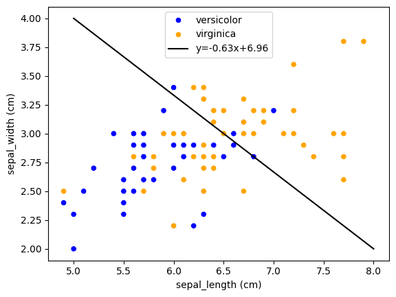

```python
sns.scatterplot(x="sepal_length (cm)", y="sepal_width (cm)", hue="label", palette = ['blue', 'orange'] ,data= versicolor_virginica_df)
plt.plot([5, 8], [4, 2], 'black', label = "y=-0.63x+6.96")
plt.legend()
plt.rcParams['savefig.dpi'] = 300
plt.show()
```

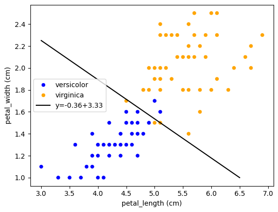

```python
sns.scatterplot(x="petal_length (cm)", y="petal_width (cm)", hue="label", palette = ['blue', 'orange'] ,data= versicolor_virginica_df)
plt.plot([3, 6.5], [2.25, 1], 'black', label = "y=-0.36+3.33")
plt.legend()
plt.rcParams['savefig.dpi'] = 300
plt.show()
```

standard equations

0.63x+y-6.96=0 0.36x+y-3.33=0

```python
dec_bound_vec = np.array([0.63, 1.00, -6.96])
features = versicolor_virginica_df[["sepal_length (cm)", "sepal_width (cm)"]].values
class_names = ["versicolor", "virginica"]
pred_labels = linear_decision_boundary_classifier(dec_bound_vec, features, class_names=class_names)
print(pred_labels)

print (accuracy_score(versicolor_virginica_df['label'], pred_labels))
```

```
['virginica' 'virginica' 'virginica' 'versicolor' 'versicolor'
 'versicolor' 'virginica' 'versicolor' 'virginica' 'versicolor'
 'versicolor' 'versicolor' 'versicolor' 'versicolor' 'versicolor'
 'virginica' 'versicolor' 'versicolor' 'versicolor' 'versicolor'
 'versicolor' 'versicolor' 'versicolor' 'versicolor' 'versicolor'
 'virginica' 'virginica' 'virginica' 'versicolor' 'versicolor'
 'versicolor' 'versicolor' 'versicolor' 'versicolor' 'versicolor'
 'virginica' 'virginica' 'versicolor' 'versicolor' 'versicolor'
 'versicolor' 'versicolor' 'versicolor' 'versicolor' 'versicolor'
 'versicolor' 'versicolor' 'versicolor' 'versicolor' 'versicolor'
 'virginica' 'versicolor' 'virginica' 'versicolor' 'virginica' 'virginica'
 'versicolor' 'virginica' 'versicolor' 'virginica' 'virginica'
 'versicolor' 'virginica' 'versicolor' 'versicolor' 'virginica'
 'virginica' 'virginica' 'virginica' 'versicolor' 'virginica' 'versicolor'
 'virginica' 'versicolor' 'virginica' 'virginica' 'versicolor'
 'versicolor' 'versicolor' 'virginica' 'virginica' 'virginica'
 'versicolor' 'versicolor' 'versicolor' 'virginica' 'virginica'
 'virginica' 'versicolor' 'virginica' 'virginica' 'virginica' 'versicolor'
 'virginica' 'virginica' 'virginica' 'versicolor' 'virginica' 'virginica'
 'versicolor']
0.69
```

```python
dec_bound_vec = np.array([0.36, 1.00, -3.33])
features = versicolor_virginica_df[["petal_length (cm)", "petal_width (cm)"]].values
class_names = ["versicolor", "virginica"]
pred_labels = linear_decision_boundary_classifier(dec_bound_vec, features, class_names=class_names)
print(pred_labels)

print (accuracy_score(versicolor_virginica_df['label'], pred_labels))
```

```
['versicolor' 'versicolor' 'versicolor' 'versicolor' 'versicolor'
 'versicolor' 'versicolor' 'versicolor' 'versicolor' 'versicolor'
 'versicolor' 'versicolor' 'versicolor' 'versicolor' 'versicolor'
 'versicolor' 'versicolor' 'versicolor' 'versicolor' 'versicolor'
 'virginica' 'versicolor' 'versicolor' 'versicolor' 'versicolor'
 'versicolor' 'versicolor' 'virginica' 'versicolor' 'versicolor'
 'versicolor' 'versicolor' 'versicolor' 'virginica' 'versicolor'
 'versicolor' 'versicolor' 'versicolor' 'versicolor' 'versicolor'
 'versicolor' 'versicolor' 'versicolor' 'versicolor' 'versicolor'
 'versicolor' 'versicolor' 'versicolor' 'versicolor' 'versicolor'
 'virginica' 'virginica' 'virginica' 'virginica' 'virginica' 'virginica'
 'versicolor' 'virginica' 'virginica' 'virginica' 'virginica' 'virginica'
 'virginica' 'virginica' 'virginica' 'virginica' 'virginica' 'virginica'
 'virginica' 'versicolor' 'virginica' 'virginica' 'virginica' 'virginica'
 'virginica' 'virginica' 'virginica' 'virginica' 'virginica' 'virginica'
 'virginica' 'virginica' 'virginica' 'virginica' 'virginica' 'virginica'
 'virginica' 'virginica' 'virginica' 'virginica' 'virginica' 'virginica'
 'virginica' 'virginica' 'virginica' 'virginica' 'virginica' 'virginica'
 'virginica' 'virginica']
0.95
```

```python
setosa_training_df = pd.read_csv("setosa_training.csv")
training = setosa_training_df[["sepal_length (cm)", "sepal_width (cm)"]].values
trainingLabel = setosa_training_df[["label"]].values

trainingLabel = np.ravel(trainingLabel)

le.fit(trainingLabel)

print(le.transform(trainingLabel))
```

```
[1 1 1 1 1 0 1 1 0 0 1 1 0 1 0 1 0 1 1 1 1 1 1 1 1 1 0 1 0 0 1 1 0 0 1 1 1
 1 1 1 1 1 1 0 0 1 1 1 0 0 1 0 1 1 1 0 1 0 1 1 1 1 0 0 1 0 0 0 0 1 0 0 1 1
 1 1 1 1 1 1 0 1 1 0 0 1 1 0 1 0 1 1 1 1 0 1 1 0 1 1 0 1 0 0 0 1 1 1]
```

```python
setosa_testing_df = pd.read_csv("setosa_testing.csv")
testing= setosa_testing_df[["sepal_length (cm)", "sepal_width (cm)"]].values
testingLabel = setosa_testing_df[["label"]].values

testingLabel = np.ravel(testingLabel)

le.fit(testingLabel)

print(le.transform(testingLabel))
```

```
[1 0 0 0 1 0 0 1 1 1 0 1 1 1 1 1 1 1 1 1 1 1 0 1 0 1 1 0 1 1 0 1 0 0 1 1 1
 0 1 1 1 1]
```

```python
setosa_target_df = pd.read_csv("setosa_target.csv")
target = setosa_target_df[["sepal_length (cm)", "sepal_width (cm)"]].values
targetLabel = setosa_target_df[["label"]].values

targetLabel = np.ravel(targetLabel)

le.fit(targetLabel)

print(le.transform(targetLabel))
```

```
[0 1 1 1 0 1 0 0 1 0 0 1 1 0 1 1 1 1 1 1 1 1 1 0 0 1 1 1 0 1 0 1 1 1 0 1 1
 0 1 1 1 1 1 1]
```

```python
model = LogisticRegression(random_state=0)
model.fit(training, trainingLabel)

print(model.coef_)
print(model.intercept_)
```

```
[[ 3.16919523 -2.57279307]]
[-9.15324246]
```

3.16919523x-2.57279307y-9.15324246=0 y=1.2318x-3.5577

```python
train_predictions = model.predict(training)
train_accuracy = accuracy_score(trainingLabel, train_predictions)
print(train_accuracy)
```

```
1.0
```

```python
test_predictions = model.predict(testing)
test_accuracy = accuracy_score(testingLabel, test_predictions)
print(test_accuracy)
```

```
0.9761904761904762
```

```python
target_predictions = model.predict(target)
target_accuracy = accuracy_score(targetLabel, target_predictions)
print(target_accuracy)
```

```
0.9772727272727273
```

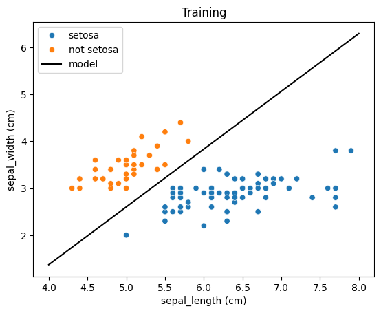

```python
sns.scatterplot(x="sepal_length (cm)", y="sepal_width (cm)", hue="label", data= setosa_training_df)
plt.plot([4, 8], [1.3695, 6.2967], 'black', label = "model")
plt.title("Training")
plt.legend()
plt.rcParams['savefig.dpi'] = 300
plt.show()
```

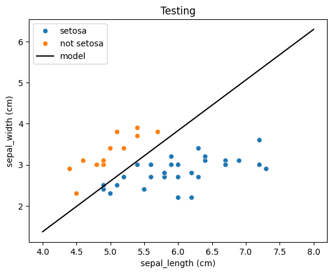

```python
sns.scatterplot(x="sepal_length (cm)", y="sepal_width (cm)", hue="label", data= setosa_testing_df)
plt.plot([4, 8], [1.3695, 6.2967], 'black', label = "model")
plt.title("Testing")
plt.legend()
plt.rcParams['savefig.dpi'] = 300
plt.show()
```

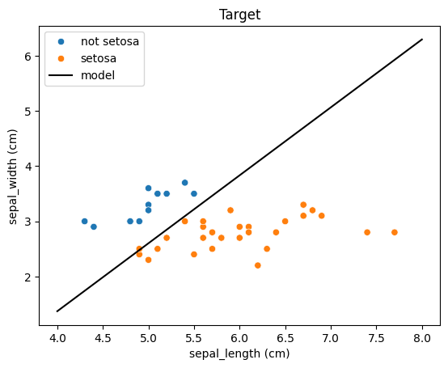

```python
sns.scatterplot(x="sepal_length (cm)", y="sepal_width (cm)", hue="label", data= setosa_target_df)
plt.plot([4, 8], [1.3695, 6.2967], 'black', label = "model")
plt.title("Target")
plt.legend()
plt.rcParams['savefig.dpi'] = 300
plt.show()
```

```python
svm_model = SVC(C=1000.0, kernel='linear')
svm_model.fit(training, trainingLabel)

print(svm_model.coef_)
print(svm_model.intercept_)
```

```
[[ 3.33308631 -3.33266273]]
[-7.66746092]
```

```python
train_pred = svm_model.predict(training)
train_accuracy = accuracy_score(trainingLabel, train_pred)
print(train_accuracy)
```

```
1.0
```

```python
test_pred = svm_model.predict(testing)
test_accuracy = accuracy_score(testingLabel, test_pred)
print(test_accuracy)
```

```
1.0
```

```python
target_pred = svm_model.predict(target)
target_accuracy = accuracy_score(targetLabel, target_pred)
print(target_accuracy)
```

```
1.0
```

3.33308631x-3.33266273y-7.66746092=0 y=1.0001x-2.3007

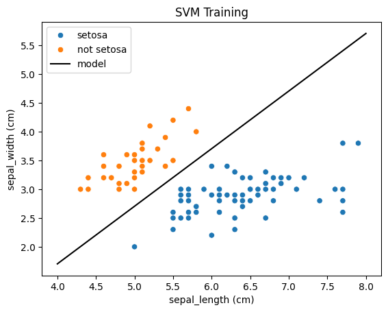

```python
sns.scatterplot(x="sepal_length (cm)", y="sepal_width (cm)", hue="label", data= setosa_training_df)
plt.plot([4, 8], [1.7033, 5.7073], 'black', label = "model")
plt.title("SVM Training")
plt.legend()
plt.rcParams['savefig.dpi'] = 300
plt.show()
```

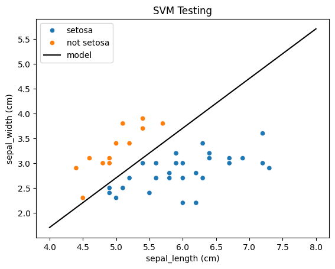

```python
sns.scatterplot(x="sepal_length (cm)", y="sepal_width (cm)", hue="label", data= setosa_testing_df)
plt.plot([4, 8], [1.7033, 5.7073], 'black', label = "model")
plt.title("SVM Testing")
plt.legend()
plt.rcParams['savefig.dpi'] = 300
plt.show()
```

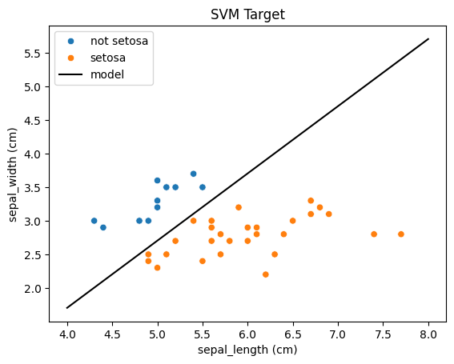

```python
sns.scatterplot(x="sepal_length (cm)", y="sepal_width (cm)", hue="label", data= setosa_target_df)
plt.plot([4, 8], [1.7033, 5.7073], 'black', label = "model")
plt.title("SVM Target")
plt.legend()
plt.rcParams['savefig.dpi'] = 300
plt.show()
```